# Writing articles and reproducible documents `R`

Anna Quaglieri

27/02/2019

Talking `R Markdown`, probably the main distinction between writing a *reproducible report of your analysis* or a *journal article* is the journal template and layout which is often provided as a LaTeX template by the editors. In my view, if you want to write your robust and reproducible paper in `R` today, you are faced with two options based on whether the journal you want to submit to has a LaTex template already built in R Markdown.

# Ideal options: the journal you want has already a LaTex template in `R Markdown`

## The `rticles` package

Have a look at the [`rticles` package](https://github.com/rstudio/rticles) to see if your journal is listed there. This package is a collaborative effort to create `Rmd` LaTeX templates for various journals.

```r
install.packages("rticles")

# Or the dev version
# devtools::install_github("rstudio/rticles")

library(rticles)
```

## The `BiocWorkflowTools` package: F1000 LaTex template for Bioconductor workflows

If you work in Bioinformatics and you developed a [Bioconductor](https://www.bioconductor.org/) workflow then you might want to submit your paper to [F1000](https://f1000research.com/) and the [BiocWorkflowTools](https://www.bioconductor.org/packages/devel/bioc/vignettes/BiocWorkflowTools/inst/doc/Generate_F1000_Latex.html) is exactly what you need!

```r
if (!requireNamespace("BiocManager", quietly=TRUE))
    install.packages("BiocManager")
BiocManager::install('BiocWorkflowTools')
library(BiocWorkflowTools)
```

## Load your template in a click and start writing!

Once you found your journal, create a new `Rmd` and choose your template as in Figure 1!

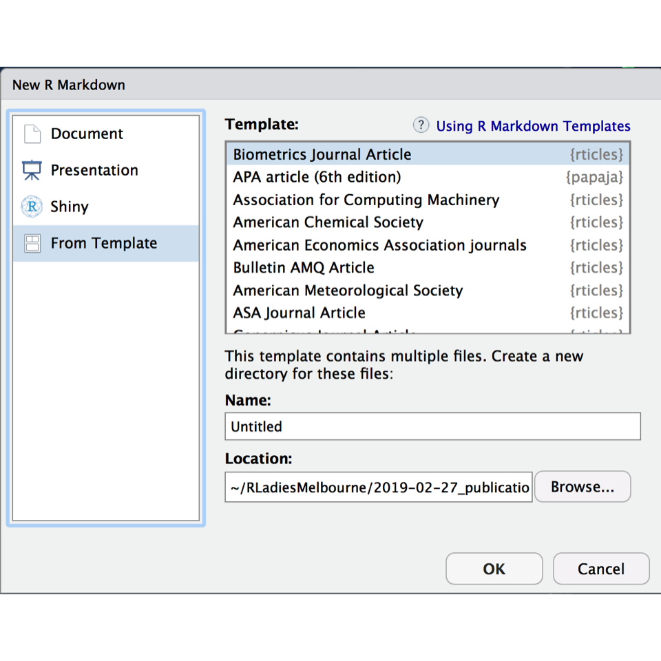

Figure 1: Choose your `rticles` template.

The journal template will offer all the necessary examples to show you how to cross reference sections, figures, tables and equations as well as you can check the final result by knitting the document.

# My case: the journals I wanted to submit did not have an `Rmd` LaTex template. No drama!

## My mind-workflow to setup myself to write a paper in `Rmd`

The first thing that I did was to decide what I wanted.

- I had a few journals in mind but not one defined: I needed a **general structure** (main manuscript with sections, additional files)
- I wanted a robust way to **cross-reference** figures/tables/euqations/sections
- I wanted to be able to output the article in both `pdf`, `word` and `LaTex` to come towards my co-authors and how they are used to give feedbacks
- I wanted to include a bibliography files
- I wanted to be able to create a file of additional information where tables and figures would be numbered distinctly from the main manuscript (e.g. S1, S2 etc…)

## `bookdown` is the answer!

- Generate [single flexible documents within the `bookdown` approach](https://bookdown.org/yihui/rmarkdown/bookdown-output.html#a-single-document)
- Easy and consistent [Cross-referencing](https://bookdown.org/yihui/rmarkdown/bookdown-markdown.html#cross-referencing)
- Different [output formats](https://bookdown.org/yihui/rmarkdown/bookdown-output.html)
- Tweak the `YAML` of you `Rmd` to combine different `Rmd` with `site: bookdown::bookdown_site` and tweak the LaTex headers to achieve more flexibility in figure numbering.
- Add your `.bib` file by adding `bibliography: biblio.bib` in the `YAML`

Reports, articles and books can be easily generated using the `library(bookdown)`. This package was written to allow a flexible and comprehensve environment to author books in `R` and the author, Yihui Xie, made the same framework available to [write single documents](https://bookdown.org/yihui/rmarkdown/bookdown-output.html#a-single-document). Writing everyday reproducible documents or journal articles requires a very similar infrastructure and, at the end of the day, there is very little substantial difference between them. Yihui wrote a super comprehensive book https://bookdown.org/yihui/bookdown/ about all things `bookdown`! Once you master one type of document, you are pretty well set to master them all!

# Minimal article with `bookdown::pdf_document2:`

In the `bookdown-article-minimal-example/` folder I created a minimal example to create an article with `bookdown`.

## `YAML` setup

The `YAML` is what you need to define the layout or theme of your documents. You can also add plain LaTex code in here and tell `bookdown` how you want your `Rmd` files to be knitted together. By default, `bookdown` bind together files in numerical order. For example, see the `Rmd` files in the [`bookdown-article-minimal-example/ folder`](https://github.com/R-LadiesMelbourne/2019-02-27-publications-ready-documents-with-Rmarkdown/tree/master/Anna-writing-articles/bookdown-article-minimal-example). The firt part would be `index.Rmd`, followed by `02-Additional_files` and `03-References.Rmd`.

### Allow the `bookdown` cross-referencing approach

```yaml
---
title: "A minimal paper"
author: "Anna Quaglieri"
output:
  bookdown::pdf_document2:
    toc: no
    keep_tex: true
---
```

### Add abstract, authors and bibliography

```yaml
---
title: "A minimal paper"
author: "Anna Quaglieri"
output:
  bookdown::pdf_document2:
    toc: no
    keep_tex: true

author: |
  | Author 1^[Corresponding author: email@email.com] $^1$, Author 2 $^1$, Author 3 $^2$
  | $^1$Affiliation1,  $^2$Affiliation2

abstract: |
  Your abstract goes here...

bibliography: biblio.bib

---
```

### Allow to split the article in separate files and combine them when knitting: `bookdown::bookdown_site`

```yaml
---
title: "A minimal paper"
author: "Anna Quaglieri"

site: bookdown::bookdown_site

output:
  bookdown::pdf_document2:
    toc: no
    keep_tex: true

author: |
  | Author 1^[Corresponding author: email@email.com] $^1$, Author 2 $^1$, Author 3 $^2$
  | $^1$Affiliation1,  $^2$Affiliation2

abstract: |
  Your abstract goes here...

bibliography: biblio.bib

---
```

### Allow re-numbering of files in supplementary files

I found the following LaTex code on this [StackOverflow thread](https://stackoverflow.com/questions/50223141/rmarkdown-bookdown-separate-figure-numbering-for-supplemental-section?rq=1).

```yaml
---
title: "A minimal paper"
author: "Anna Quaglieri"
output:
  bookdown::pdf_document2:
    toc: no
    keep_tex: true

author: |
  | Author 1^[Corresponding author: email@email.com] $^1$, Author 2 $^1$, Author 3 $^2$
  | $^1$Affiliation1,  $^2$Affiliation2

abstract: |
  Your abstract goes here...

bibliography: biblio.bib

fontsize: 12pt
header-includes:
  \usepackage{float} \floatplacement{figure}{H}
  \newcommand{\beginsupplement}{\setcounter{table}{0}  \renewcommand{\thetable}{S\arabic{table}} \setcounter{figure}{0} \renewcommand{\thefigure}{S\arabic{figure}}}
  \usepackage{setspace}\doublespacing
  \usepackage{lineno}
  \linenumbers
---
```

### Some extra `LaTex` options: line numbering and spacing!

- Try removing the following from the `YAML`!

```yaml
---
\usepackage{setspace}\doublespacing
\usepackage{lineno}
\linenumbers
---
```

- Try adding the LaTex command `\usepackage{endfloat}` after `header-includes:` in the `YAML`

## The body of your article

Now that you are setup with the YAML stucture you can start populating your manuscript with for figures, tables, equations, code and texts! In the minimal example that I created I created two separated `Rmd` files for the main manuscript and the additional files. This is because the manuscript could become really long and you might be better of splitting the two parts.

## Approaches to real-time collaboration with co-authors

- Setup a `GitHub` account and push/pull changes with your collaborators
- Checkout [Overleaf](https://www.overleaf.com/) for real-time collaboration on LaTex file. Have a read at this [blog post](https://medium.com/@arinbasu/a-tutorial-on-how-to-interface-an-r-notebook-with-overleaf-11f23c306cfd) that discuss working with Git, RStudio and Overleaf at the same time. The drawback is that, while it is easy to go from `Rmd` to `.tex` with the `YAML` option `keep_tex: true`, it is not the same on the other way around. However, it is worth checking it out since it offers plenty of journal LaTex templates!

# Aknowledgements

- [bookdown: Authoring Books and Technical Documents with R Markdown](https://bookdown.org/yihui/bookdown/)
- *Interface R with Overleaf* https://medium.com/@arinbasu/a-tutorial-on-how-to-interface-an-r-notebook-with-overleaf-11f23c306cfd
- Minimal `bookdown` template for scientific papers http://landscapeportal.org/blog/2017/09/06/r-markdown-template-for-a-scientific-manuscript/
- [Earo Wang papers on GitHub](https://github.com/earowang/paper-calendar-vis) and helpful suggestions via email!

Written by [Anna Quaglieri](https://github.com/annaquaglieri16)